## import the required libraries

```python
import numpy as np
import pandas as pd
import seaborn as sns
import matplotlib.ticker as mtick
import matplotlib.pyplot as plt
%matplotlib inline
```

```python
df = pd.read_csv("E:\dataset\churn.csv")
```

```python
df
```

|  | cID | gender | SeniorCitizen | Partner | Dependents | tenure | PhoneService | MultipleLines | InternetService | OnlineSecurity | ... | DeviceProtection | TechSupport | TV_Streaming | Movie_Streaming | Contract | PaperlessBilling | Method_Payment | Charges_Month | TotalCharges | Churn |
| --- | --- | --- | --- | --- | --- | --- | --- | --- | --- | --- | --- | --- | --- | --- | --- | --- | --- | --- | --- | --- | --- |
| 0 | 4223-BKEOR | Female | 0 | No | Yes | 21 | Yes | No | DSL | Yes | ... | Yes | No | No | Yes | One year | No | Mailed check | 64.85 | 1336.8 | No |
| 1 | 6035-RIIOM | Female | 0 | No | No | 54 | Yes | Yes | Fiber optic | No | ... | No | No | Yes | Yes | Two year | Yes | Bank transfer (automatic) | 97.20 | 5129.45 | No |
| 2 | 3797-VTIDR | Male | 0 | Yes | No | 1 | No | No phone service | DSL | No | ... | No | No | No | No | Month-to-month | Yes | Electronic check | 23.45 | 23.45 | Yes |
| 3 | 2568-BRGYX | Male | 0 | No | No | 4 | Yes | No | Fiber optic | No | ... | No | No | No | No | Month-to-month | Yes | Electronic check | 70.20 | 237.95 | Yes |
| 4 | 2775-SEFEE | Male | 0 | No | Yes | 0 | Yes | Yes | DSL | Yes | ... | No | Yes | No | No | Two year | Yes | Bank transfer (automatic) | 61.90 |  | No |
| ... | ... | ... | ... | ... | ... | ... | ... | ... | ... | ... | ... | ... | ... | ... | ... | ... | ... | ... | ... | ... | ... |
| 5629 | 0684-AOSIH | Male | 0 | Yes | No | 1 | Yes | No | Fiber optic | Yes | ... | No | No | Yes | Yes | Month-to-month | Yes | Electronic check | 95.00 | 95 | Yes |
| 5630 | 5982-PSMKW | Female | 0 | Yes | Yes | 23 | Yes | Yes | DSL | Yes | ... | Yes | Yes | Yes | Yes | Two year | Yes | Credit card (automatic) | 91.10 | 2198.3 | No |
| 5631 | 8044-BGWPI | Male | 0 | Yes | Yes | 12 | Yes | No | No | No internet service | ... | No internet service | No internet service | No internet service | No internet service | Month-to-month | Yes | Electronic check | 21.15 | 306.05 | No |
| 5632 | 7450-NWRTR | Male | 1 | No | No | 12 | Yes | Yes | Fiber optic | No | ... | Yes | No | Yes | Yes | Month-to-month | Yes | Electronic check | 99.45 | 1200.15 | Yes |
| 5633 | 4795-UXVCJ | Male | 0 | No | No | 26 | Yes | No | No | No internet service | ... | No internet service | No internet service | No internet service | No internet service | One year | No | Credit card (automatic) | 19.80 | 457.3 | No |

5634 rows × 21 columns

```python
 df.shape
```

```
(5634, 21)
```

```python
df.describe()
```

|  | SeniorCitizen | tenure | Charges_Month |
| --- | --- | --- | --- |
| count | 5634.000000 | 5634.000000 | 5634.000000 |
| mean | 0.160809 | 32.373092 | 64.864253 |
| std | 0.367388 | 24.424539 | 30.089324 |
| min | 0.000000 | 0.000000 | 18.250000 |
| 25% | 0.000000 | 9.000000 | 35.750000 |
| 50% | 0.000000 | 29.000000 | 70.525000 |
| 75% | 0.000000 | 55.000000 | 89.937500 |
| max | 1.000000 | 72.000000 | 118.600000 |

```python
df.info()
```

```
<class 'pandas.core.frame.DataFrame'>
RangeIndex: 5634 entries, 0 to 5633
Data columns (total 21 columns):
 #   Column            Non-Null Count  Dtype
---  ------            --------------  -----
 0   cID               5634 non-null   object
 1   gender            5634 non-null   object
 2   SeniorCitizen     5634 non-null   int64
 3   Partner           5634 non-null   object
 4   Dependents        5634 non-null   object
 5   tenure            5634 non-null   int64
 6   PhoneService      5634 non-null   object
 7   MultipleLines     5634 non-null   object
 8   InternetService   5634 non-null   object
 9   OnlineSecurity    5634 non-null   object
 10  OnlineBackup      5634 non-null   object
 11  DeviceProtection  5634 non-null   object
 12  TechSupport       5634 non-null   object
 13  TV_Streaming      5634 non-null   object
 14  Movie_Streaming   5634 non-null   object
 15  Contract          5634 non-null   object
 16  PaperlessBilling  5634 non-null   object
 17  Method_Payment    5634 non-null   object
 18  Charges_Month     5634 non-null   float64
 19  TotalCharges      5634 non-null   object
 20  Churn             5634 non-null   object
dtypes: float64(1), int64(2), object(18)
memory usage: 924.5+ KB
```

```python
df.isnull().sum()
```

```
cID                 0
gender              0
SeniorCitizen       0
Partner             0
Dependents          0
tenure              0
PhoneService        0
MultipleLines       0
InternetService     0
OnlineSecurity      0
OnlineBackup        0
DeviceProtection    0
TechSupport         0
TV_Streaming        0
Movie_Streaming     0
Contract            0
PaperlessBilling    0
Method_Payment      0
Charges_Month       0
TotalCharges        0
Churn               0
dtype: int64
```

```python
df.columns
```

```
Index(['cID', 'gender', 'SeniorCitizen', 'Partner', 'Dependents', 'tenure',
       'PhoneService', 'MultipleLines', 'InternetService', 'OnlineSecurity',
       'OnlineBackup', 'DeviceProtection', 'TechSupport', 'TV_Streaming',
       'Movie_Streaming', 'Contract', 'PaperlessBilling', 'Method_Payment',
       'Charges_Month', 'TotalCharges', 'Churn'],
      dtype='object')
```

## Checking the data types of all the columns

```python
df.dtypes
```

```
cID                  object
gender               object
SeniorCitizen         int64
Partner              object
Dependents           object
tenure                int64
PhoneService         object
MultipleLines        object
InternetService      object
OnlineSecurity       object
OnlineBackup         object
DeviceProtection     object
TechSupport          object
TV_Streaming         object
Movie_Streaming      object
Contract             object
PaperlessBilling     object
Method_Payment       object
Charges_Month       float64
TotalCharges         object
Churn                object
dtype: object
```

## Check the descriptive statistics of numeric variables

```python
df.describe()
```

|  | SeniorCitizen | tenure | Charges_Month |
| --- | --- | --- | --- |
| count | 5634.000000 | 5634.000000 | 5634.000000 |
| mean | 0.160809 | 32.373092 | 64.864253 |
| std | 0.367388 | 24.424539 | 30.089324 |
| min | 0.000000 | 0.000000 | 18.250000 |
| 25% | 0.000000 | 9.000000 | 35.750000 |
| 50% | 0.000000 | 29.000000 | 70.525000 |
| 75% | 0.000000 | 55.000000 | 89.937500 |
| max | 1.000000 | 72.000000 | 118.600000 |

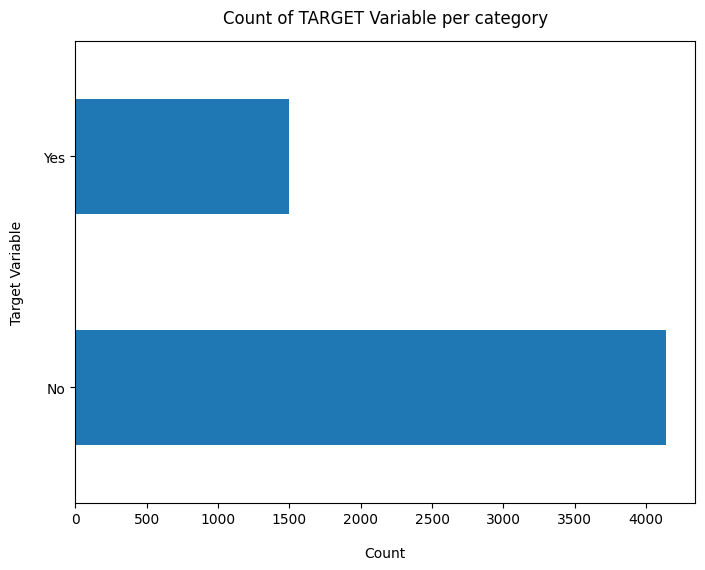

```python
df['Churn'].value_counts().plot(kind='barh',figsize=(8,6))
plt.xlabel("Count",labelpad=14)
plt.ylabel("Target Variable",labelpad=14)
plt.title("Count of TARGET Variable per category", y=1.02);
```

```python
100*df['Churn'].value_counts()/len(df['Churn'])
```

```
Churn
No     73.446929
Yes    26.553071
Name: count, dtype: float64
```

```python
df['Churn'].value_counts()
```

```
Churn
No     4138
Yes    1496
Name: count, dtype: int64
```

## concise summary of dataframe ,as we have too many columns, we are using the verbose = True mode

```python
df.info(verbose=True)
```

```
<class 'pandas.core.frame.DataFrame'>
RangeIndex: 5634 entries, 0 to 5633
Data columns (total 21 columns):
 #   Column            Non-Null Count  Dtype
---  ------            --------------  -----
 0   cID               5634 non-null   object
 1   gender            5634 non-null   object
 2   SeniorCitizen     5634 non-null   int64
 3   Partner           5634 non-null   object
 4   Dependents        5634 non-null   object
 5   tenure            5634 non-null   int64
 6   PhoneService      5634 non-null   object
 7   MultipleLines     5634 non-null   object
 8   InternetService   5634 non-null   object
 9   OnlineSecurity    5634 non-null   object
 10  OnlineBackup      5634 non-null   object
 11  DeviceProtection  5634 non-null   object
 12  TechSupport       5634 non-null   object
 13  TV_Streaming      5634 non-null   object
 14  Movie_Streaming   5634 non-null   object
 15  Contract          5634 non-null   object
 16  PaperlessBilling  5634 non-null   object
 17  Method_Payment    5634 non-null   object
 18  Charges_Month     5634 non-null   float64
 19  TotalCharges      5634 non-null   object
 20  Churn             5634 non-null   object
dtypes: float64(1), int64(2), object(18)
memory usage: 924.5+ KB
```

[output not shown]

[figure not shown]

```python
missing=pd.DataFrame((df.isnull().sum())*100/df.shape[0]).reset_index()
plt.figure(figsize=(16,5))
ax=sns.pointplot()('index',0,data=missing)
plt.xticks(rotation=90,fontsize=7)
plt.title("Percentage of Missing values")
plt.ylabel("PERCENTAGE")
plt.show()
```

```python
df.TotalCharges = pd.to_numeric(df.TotalCharges, errors='coerce')
df.isnull().sum()
```

```
cID                  0
gender               0
SeniorCitizen        0
Partner              0
Dependents           0
tenure               0
PhoneService         0
MultipleLines        0
InternetService      0
OnlineSecurity       0
OnlineBackup         0
DeviceProtection     0
TechSupport          0
TV_Streaming         0
Movie_Streaming      0
Contract             0
PaperlessBilling     0
Method_Payment       0
Charges_Month        0
TotalCharges        10
Churn                0
dtype: int64
```

```python
  df.loc[df['TotalCharges'].isnull()==True]
```

|  | cID | gender | SeniorCitizen | Partner | Dependents | tenure | PhoneService | MultipleLines | InternetService | OnlineSecurity | ... | DeviceProtection | TechSupport | TV_Streaming | Movie_Streaming | Contract | PaperlessBilling | Method_Payment | Charges_Month | TotalCharges | Churn |
| --- | --- | --- | --- | --- | --- | --- | --- | --- | --- | --- | --- | --- | --- | --- | --- | --- | --- | --- | --- | --- | --- |
| 4 | 2775-SEFEE | Male | 0 | No | Yes | 0 | Yes | Yes | DSL | Yes | ... | No | Yes | No | No | Two year | Yes | Bank transfer (automatic) | 61.90 | NaN | No |
| 282 | 1371-DWPAZ | Female | 0 | Yes | Yes | 0 | No | No phone service | DSL | Yes | ... | Yes | Yes | Yes | No | Two year | No | Credit card (automatic) | 56.05 | NaN | No |
| 2419 | 3213-VVOLG | Male | 0 | Yes | Yes | 0 | Yes | Yes | No | No internet service | ... | No internet service | No internet service | No internet service | No internet service | Two year | No | Mailed check | 25.35 | NaN | No |
| 2734 | 2923-ARZLG | Male | 0 | Yes | Yes | 0 | Yes | No | No | No internet service | ... | No internet service | No internet service | No internet service | No internet service | One year | Yes | Mailed check | 19.70 | NaN | No |
| 2903 | 7644-OMVMY | Male | 0 | Yes | Yes | 0 | Yes | No | No | No internet service | ... | No internet service | No internet service | No internet service | No internet service | Two year | No | Mailed check | 19.85 | NaN | No |
| 3974 | 5709-LVOEQ | Female | 0 | Yes | Yes | 0 | Yes | No | DSL | Yes | ... | Yes | No | Yes | Yes | Two year | No | Mailed check | 80.85 | NaN | No |
| 5023 | 3115-CZMZD | Male | 0 | No | Yes | 0 | Yes | No | No | No internet service | ... | No internet service | No internet service | No internet service | No internet service | Two year | No | Mailed check | 20.25 | NaN | No |
| 5030 | 2520-SGTTA | Female | 0 | Yes | Yes | 0 | Yes | No | No | No internet service | ... | No internet service | No internet service | No internet service | No internet service | Two year | No | Mailed check | 20.00 | NaN | No |
| 5343 | 4472-LVYGI | Female | 0 | Yes | Yes | 0 | No | No phone service | DSL | Yes | ... | Yes | Yes | Yes | No | Two year | Yes | Bank transfer (automatic) | 52.55 | NaN | No |
| 5599 | 4367-NUYAO | Male | 0 | Yes | Yes | 0 | Yes | Yes | No | No internet service | ... | No internet service | No internet service | No internet service | No internet service | Two year | No | Mailed check | 25.75 | NaN | No |

10 rows × 21 columns

```python
 # Removing missing values
df.dropna(how='any', inplace=True)
```

```python
# Get the max tenure
print(df['tenure'].max())
```

```
72
```

```python
# Group the tenure in bins of 12 months
labels = ["{0} - {1}".format(i, i+11) for i in range(1, 72, 12)]

df['tenure_group'] = pd.cut(df.tenure, range(1, 80, 12), right=False, labels=labels)
```

```python
df['tenure_group'].value_counts()
```

```
tenure_group
1 - 12     1730
61 - 72    1110
13 - 24     815
25 - 36     681
49 - 60     662
37 - 48     626
Name: count, dtype: int64
```

```python
#drop column customerID and tenure
df.drop(columns=['cID','tenure'], axis=1, inplace=True)
df.head()
```

|  | gender | SeniorCitizen | Partner | Dependents | PhoneService | MultipleLines | InternetService | OnlineSecurity | OnlineBackup | DeviceProtection | TechSupport | TV_Streaming | Movie_Streaming | Contract | PaperlessBilling | Method_Payment | Charges_Month | TotalCharges | Churn | tenure_group |
| --- | --- | --- | --- | --- | --- | --- | --- | --- | --- | --- | --- | --- | --- | --- | --- | --- | --- | --- | --- | --- |
| 0 | Female | 0 | No | Yes | Yes | No | DSL | Yes | No | Yes | No | No | Yes | One year | No | Mailed check | 64.85 | 1336.80 | No | 13 - 24 |
| 1 | Female | 0 | No | No | Yes | Yes | Fiber optic | No | Yes | No | No | Yes | Yes | Two year | Yes | Bank transfer (automatic) | 97.20 | 5129.45 | No | 49 - 60 |
| 2 | Male | 0 | Yes | No | No | No phone service | DSL | No | No | No | No | No | No | Month-to-month | Yes | Electronic check | 23.45 | 23.45 | Yes | 1 - 12 |
| 3 | Male | 0 | No | No | Yes | No | Fiber optic | No | No | No | No | No | No | Month-to-month | Yes | Electronic check | 70.20 | 237.95 | Yes | 1 - 12 |
| 5 | Male | 0 | No | No | Yes | No | Fiber optic | No | No | No | No | No | No | Month-to-month | Yes | Electronic check | 69.55 | 521.35 | No | 1 - 12 |

# Data Exploration

*1. *plot distribution of individual predictors by churn

## Univariate Analysis

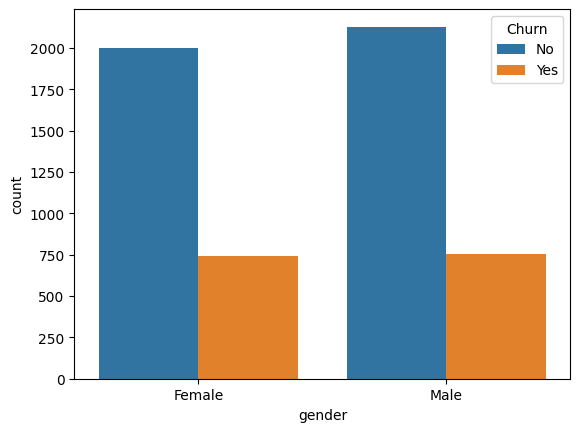

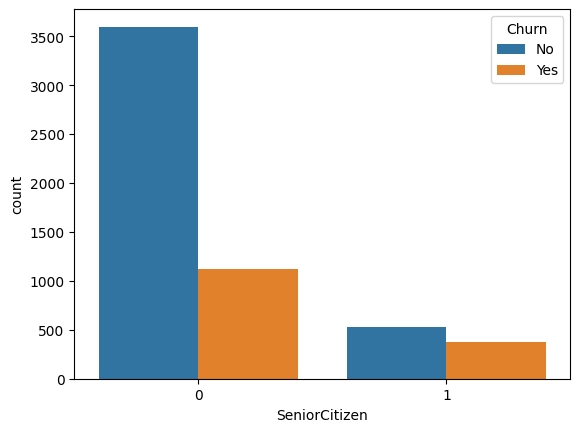

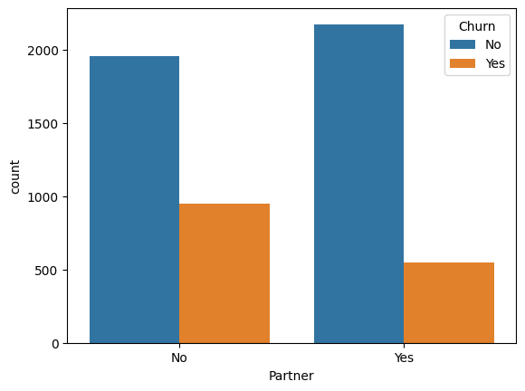

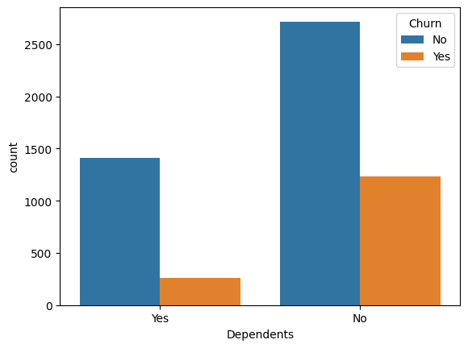

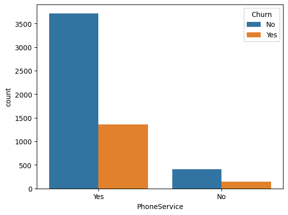

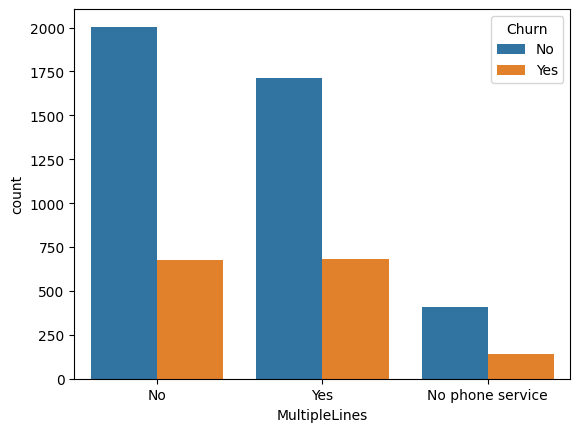

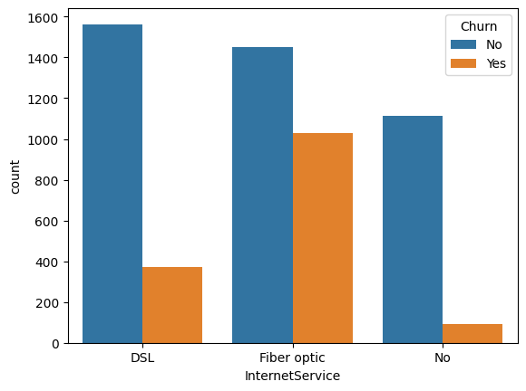

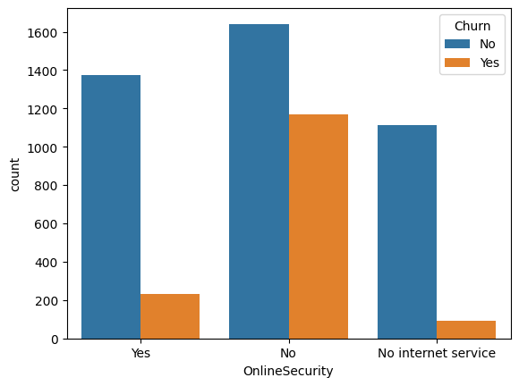

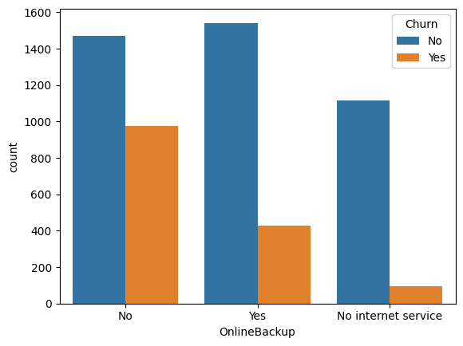

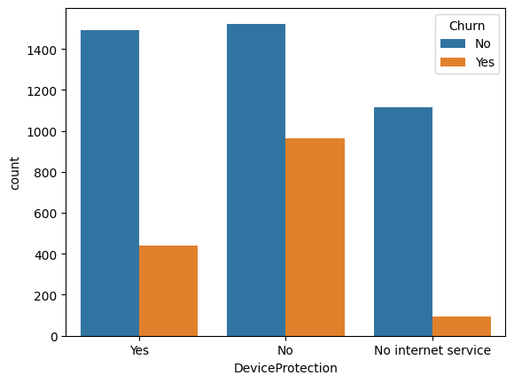

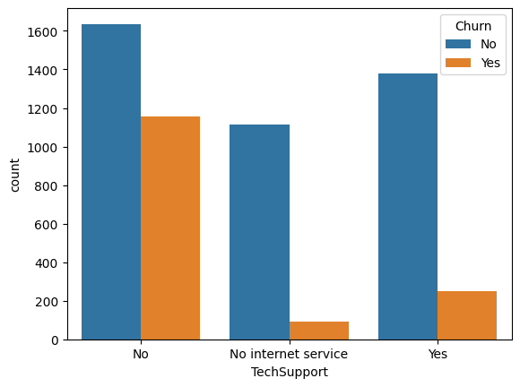

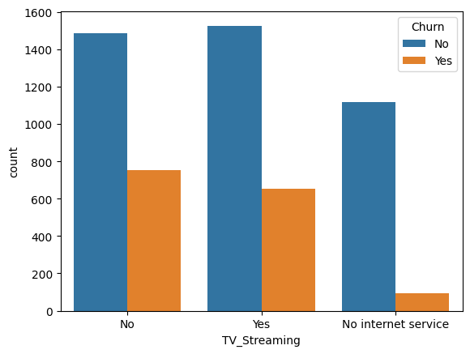

[5 more figures not shown]

```python
for i, predictor in enumerate(df.drop(columns=['Churn', 'TotalCharges', 'Charges_Month'])):
    plt.figure(i)
    sns.countplot(data=df, x=predictor, hue='Churn')
```

```python
df['Churn'] = np.where(df.Churn=='Yes',1,0)
```

df.head()

*Convert all the variables into dummy variables

```python
df_dummies=pd.get_dummies(df)
df_dummies.head()
```

|  | SeniorCitizen | Charges_Month | TotalCharges | Churn | gender_Female | gender_Male | Partner_No | Partner_Yes | Dependents_No | Dependents_Yes | ... | Method_Payment_Bank transfer (automatic) | Method_Payment_Credit card (automatic) | Method_Payment_Electronic check | Method_Payment_Mailed check | tenure_group_1 - 12 | tenure_group_13 - 24 | tenure_group_25 - 36 | tenure_group_37 - 48 | tenure_group_49 - 60 | tenure_group_61 - 72 |
| --- | --- | --- | --- | --- | --- | --- | --- | --- | --- | --- | --- | --- | --- | --- | --- | --- | --- | --- | --- | --- | --- |
| 0 | 0 | 64.85 | 1336.80 | 0 | True | False | True | False | False | True | ... | False | False | False | True | False | True | False | False | False | False |
| 1 | 0 | 97.20 | 5129.45 | 0 | True | False | True | False | True | False | ... | True | False | False | False | False | False | False | False | True | False |
| 2 | 0 | 23.45 | 23.45 | 1 | False | True | False | True | True | False | ... | False | False | True | False | True | False | False | False | False | False |
| 3 | 0 | 70.20 | 237.95 | 1 | False | True | True | False | True | False | ... | False | False | True | False | True | False | False | False | False | False |
| 5 | 0 | 69.55 | 521.35 | 0 | False | True | True | False | True | False | ... | False | False | True | False | True | False | False | False | False | False |

5 rows × 51 columns

*Relationship between Monthly Charges and Total Charges

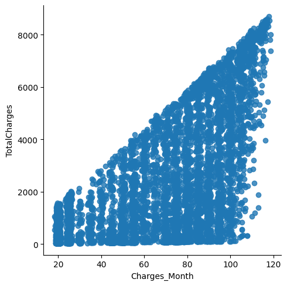

```python
sns.lmplot(data=df_dummies, x='Charges_Month', y='TotalCharges', fit_reg=False)
```

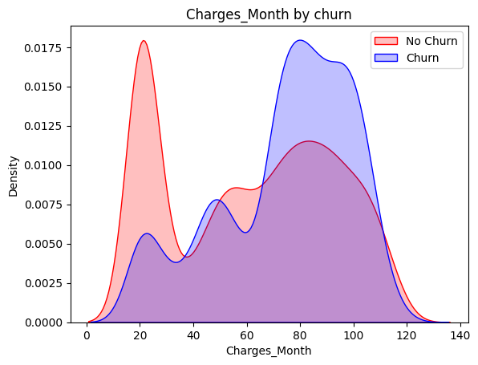

```python
mth = sns.kdeplot(df_dummies.Charges_Month[(df_dummies["Churn"] == 0)],
                  color="Red",shade=True)
mth = sns.kdeplot(df_dummies.Charges_Month[(df_dummies["Churn"] == 1)],
                  ax=mth, color="Blue", shade=True)
mth.legend(["No Churn","Churn"],loc='upper right')
mth.set_ylabel('Density')
mth.set_xlabel('Charges_Month')
mth.set_title('Charges_Month by churn')
```

- Build a corelation of all predictors with 'Churn'

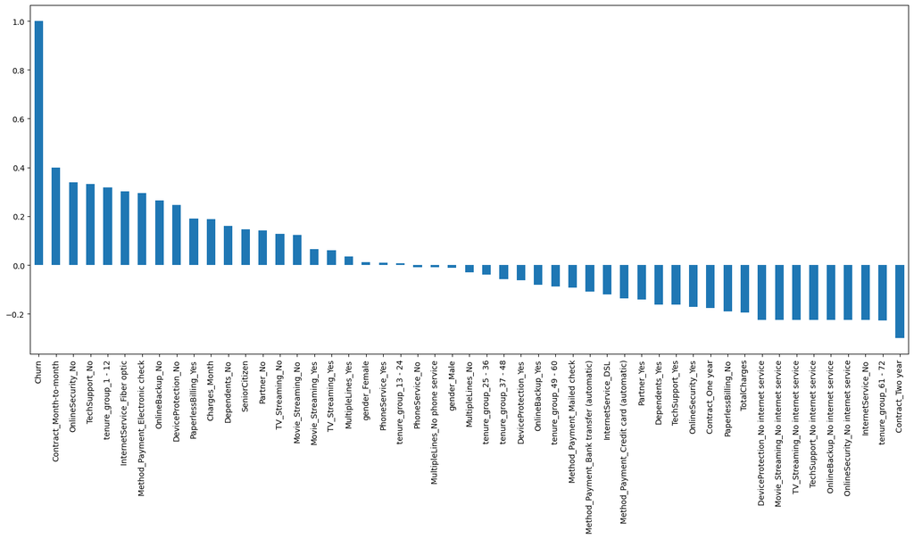

```python
plt.figure(figsize=(20,8))
df_dummies.corr()['Churn'].sort_values(ascending=False).plot(kind='bar')
```

*Derived Insight:* HIGH Churn seen in case of Month to month contracts, No online security, No Tech support,First year of subscription and Fibre Optics Internet Low Churn is seens in case of Long term contracts, Subscriptions without Internet service and The customers engaged for 5+ years Factors like Gender, Availability of PhoneService and # of multiple lines have almost NO impact on Churn This is also evident from the Heatmap below

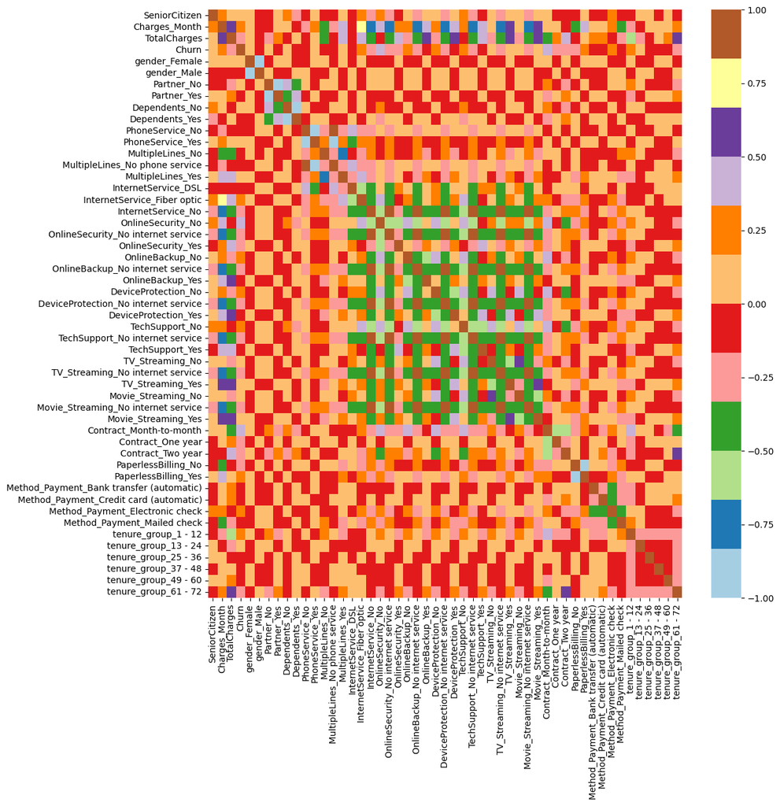

```python
plt.figure(figsize=(12,12))
sns.heatmap(df_dummies.corr(),cmap="Paired")
```

# Bivariate Analysis

```python
new_df1_target0=df.loc[df["Churn"]==0]
new_df1_target1=df.loc[df["Churn"]==1]
```

```python
def uniplot(df,col, title, hue =None):
    sns.set_style('whitegrid')
    sns.set_context('talk')
    plt.rcParams["axes.labelsize"] = 20
    plt.rcParams['axes.titlesize'] = 22
    plt.rcParams['axes.titlepad' ] = 30

    temp=pd.Series (data = hue)
    fig, ax = plt.subplots()
    width= len(df[col].unique()) + 7 + 4*len (temp.unique())
    fig.set_size_inches (width, 8)
    plt.xticks (rotation=45)
    plt.yscale('log')
    plt.title(title)
    ax=sns.countplot(data = df, x= col, order=df[col].value_counts().index, hue = hue, palette = 'bright')
    plt.show()
```

[figure not shown]

```python
uniplot(new_df1_target1,col='Partner',title='Distribution of Gender for Churned Customers',hue='gender')
```

[figure not shown]

```python
uniplot(new_df1_target0,col='Partner',title='Distribution of Gender for Churned Customers',hue='gender')
```

[figure not shown]

```python
uniplot(new_df1_target1,col='Method_Payment',title='Distribution of Method_Payment for Churned Customers',hue='gender')
```

[figure not shown]

```python
 uniplot(new_df1_target1,col='Contract',title='Distribution of Contract for Churned Customers',hue='gender')
```

[figure not shown]

```python
uniplot(new_df1_target1,col='TechSupport',title='Distribution of TechSupport for Churned Customers',hue='gender')
```

[figure not shown]

```python
uniplot(new_df1_target1,col='SeniorCitizen',title='Distribution of SeniorCitizen for Churned Customers',hue='gender')
```